# wrangle_act

```python
import pandas as pd
import numpy as np
import tweepy
import requests
import time
import os
import matplotlib.pyplot as plt
```

## Gather

### Source 1: archive

```python
#read local csv into a pandas dataframe
archive = pd.read_csv("twitter-archive-enhanced.csv")
#archive.head()
```

### Source 2: images

```python
# get tsv from the given url programatically
r = requests.get('https://d17h27t6h515a5.cloudfront.net/topher/2017/August/599fd2ad_image-predictions/image-predictions.tsv')
print(r.status_code)

# write the response to a local
with open("image_predictions.tsv", "wb") as out_file:
    out_file.write(r.content)
```

```
200
```

```python
#read local file into a pandas dataframe
images = pd.read_table("image_predictions.tsv")
#image_predictions.head()
```

### Source 3: details

**Note:** Since it takes long time, the following cell is ran only once and given as markdown below. I gathered the required info and wrote it to a txt file. While working on the data I am reading "tweet_json.txt" into a dataframe called `details`.

```
consumer_key = None
consumer_secret = None
access_token = None
access_secret = None

# authenticate twitter api
auth = tweepy.OAuthHandler(consumer_key, consumer_secret)
auth.set_access_token(access_token, access_secret)
api = tweepy.API(auth, wait_on_rate_limit=True, wait_on_rate_limit_notify = True)

# we will append info from found tweets into this list
tweet_details = []

# count how many we miss
skipped_tweet_cnt = 0

# loop on the tweet ids from archive file
for tweet_id in archive.tweet_id:

    # shall not crash if get_status gives an exception
    # we store as much as we can get
    try:
        tweet = api.get_status(tweet_id)
        tweet_details.append( dict([("id",tweet._json["id"])
                                ,("favorite_count", tweet._json["favorite_count"])
                                ,("retweet_count", tweet._json["retweet_count"])]))

    except tweepy.TweepError as e:
        print (str(type(e)) + "-" + str(e.args))
        skipped_tweet_cnt += 1
        pass

print(skipped_tweet_cnt)
retweets_and_favs = pd.DataFrame(tweet_details)

# csv is also a text file. extention does not matter as long as we know it is comma spsrated while reading.
# i could use any other delimiteri but preferred with csv for simplicity.
retweets_and_favs.to_csv("tweet_json.txt")
```

```python
# read data from local after running the cell above once.
details = pd.read_csv("tweet_json.txt")
```

**Note to reviewer for easier evaluation:** There will be 2 iterations of Assess, Clean parts. First iteration is simple and at the end I combine every source into one dataframe. Then follows a more detailed 2nd Assess and Clean part.

# Iteration 1

## Assess 1

```python
archive.head()
```

|  | tweet_id | in_reply_to_status_id | in_reply_to_user_id | timestamp | source | text | retweeted_status_id | retweeted_status_user_id | retweeted_status_timestamp | expanded_urls | rating_numerator | rating_denominator | name | doggo | floofer | pupper | puppo |
| --- | --- | --- | --- | --- | --- | --- | --- | --- | --- | --- | --- | --- | --- | --- | --- | --- | --- |
| 0 | 892420643555336193 | NaN | NaN | 2017-08-01 16:23:56 +0000 | <a href="http://twitter.com/download/iphone" r... | This is Phineas. He's a mystical boy. Only eve... | NaN | NaN | NaN | https://twitter.com/dog_rates/status/892420643... | 13 | 10 | Phineas | None | None | None | None |
| 1 | 892177421306343426 | NaN | NaN | 2017-08-01 00:17:27 +0000 | <a href="http://twitter.com/download/iphone" r... | This is Tilly. She's just checking pup on you.... | NaN | NaN | NaN | https://twitter.com/dog_rates/status/892177421... | 13 | 10 | Tilly | None | None | None | None |
| 2 | 891815181378084864 | NaN | NaN | 2017-07-31 00:18:03 +0000 | <a href="http://twitter.com/download/iphone" r... | This is Archie. He is a rare Norwegian Pouncin... | NaN | NaN | NaN | https://twitter.com/dog_rates/status/891815181... | 12 | 10 | Archie | None | None | None | None |
| 3 | 891689557279858688 | NaN | NaN | 2017-07-30 15:58:51 +0000 | <a href="http://twitter.com/download/iphone" r... | This is Darla. She commenced a snooze mid meal... | NaN | NaN | NaN | https://twitter.com/dog_rates/status/891689557... | 13 | 10 | Darla | None | None | None | None |
| 4 | 891327558926688256 | NaN | NaN | 2017-07-29 16:00:24 +0000 | <a href="http://twitter.com/download/iphone" r... | This is Franklin. He would like you to stop ca... | NaN | NaN | NaN | https://twitter.com/dog_rates/status/891327558... | 12 | 10 | Franklin | None | None | None | None |

```python
images.head()
```

|  | tweet_id | jpg_url | img_num | p1 | p1_conf | p1_dog | p2 | p2_conf | p2_dog | p3 | p3_conf | p3_dog |
| --- | --- | --- | --- | --- | --- | --- | --- | --- | --- | --- | --- | --- |
| 0 | 666020888022790149 | https://pbs.twimg.com/media/CT4udn0WwAA0aMy.jpg | 1 | Welsh_springer_spaniel | 0.465074 | True | collie | 0.156665 | True | Shetland_sheepdog | 0.061428 | True |
| 1 | 666029285002620928 | https://pbs.twimg.com/media/CT42GRgUYAA5iDo.jpg | 1 | redbone | 0.506826 | True | miniature_pinscher | 0.074192 | True | Rhodesian_ridgeback | 0.072010 | True |
| 2 | 666033412701032449 | https://pbs.twimg.com/media/CT4521TWwAEvMyu.jpg | 1 | German_shepherd | 0.596461 | True | malinois | 0.138584 | True | bloodhound | 0.116197 | True |
| 3 | 666044226329800704 | https://pbs.twimg.com/media/CT5Dr8HUEAA-lEu.jpg | 1 | Rhodesian_ridgeback | 0.408143 | True | redbone | 0.360687 | True | miniature_pinscher | 0.222752 | True |
| 4 | 666049248165822465 | https://pbs.twimg.com/media/CT5IQmsXIAAKY4A.jpg | 1 | miniature_pinscher | 0.560311 | True | Rottweiler | 0.243682 | True | Doberman | 0.154629 | True |

```python
details.head()
```

|  | Unnamed: 0 | favorite_count | id | retweet_count |
| --- | --- | --- | --- | --- |
| 0 | 0 | 39018 | 892420643555336193 | 8662 |
| 1 | 1 | 33407 | 892177421306343426 | 6361 |
| 2 | 2 | 25188 | 891815181378084864 | 4224 |
| 3 | 3 | 42374 | 891689557279858688 | 8770 |
| 4 | 4 | 40528 | 891327558926688256 | 9538 |

Note that all the tables have twitter ids. Our first aim is to understand these ids and if feasible join all three tables to one table for better assessment and easier cleaining.

```python
archive.info()
```

```
<class 'pandas.core.frame.DataFrame'>
RangeIndex: 2356 entries, 0 to 2355
Data columns (total 17 columns):
tweet_id                      2356 non-null int64
in_reply_to_status_id         78 non-null float64
in_reply_to_user_id           78 non-null float64
timestamp                     2356 non-null object
source                        2356 non-null object
text                          2356 non-null object
retweeted_status_id           181 non-null float64
retweeted_status_user_id      181 non-null float64
retweeted_status_timestamp    181 non-null object
expanded_urls                 2297 non-null object
rating_numerator              2356 non-null int64
rating_denominator            2356 non-null int64
name                          2356 non-null object
doggo                         2356 non-null object
floofer                       2356 non-null object
pupper                        2356 non-null object
puppo                         2356 non-null object
dtypes: float64(4), int64(3), object(10)
memory usage: 313.0+ KB
```

```python
images.info()
```

```
<class 'pandas.core.frame.DataFrame'>
RangeIndex: 2075 entries, 0 to 2074
Data columns (total 12 columns):
tweet_id    2075 non-null int64
jpg_url     2075 non-null object
img_num     2075 non-null int64
p1          2075 non-null object
p1_conf     2075 non-null float64
p1_dog      2075 non-null bool
p2          2075 non-null object
p2_conf     2075 non-null float64
p2_dog      2075 non-null bool
p3          2075 non-null object
p3_conf     2075 non-null float64
p3_dog      2075 non-null bool
dtypes: bool(3), float64(3), int64(2), object(4)
memory usage: 152.1+ KB
```

```python
details.info()
```

```
<class 'pandas.core.frame.DataFrame'>
RangeIndex: 2345 entries, 0 to 2344
Data columns (total 4 columns):
Unnamed: 0        2345 non-null int64
favorite_count    2345 non-null int64
id                2345 non-null int64
retweet_count     2345 non-null int64
dtypes: int64(4)
memory usage: 73.4 KB
```

It seems it is better practive to convert tweet_id column which we will later on use as index column for all of our tables to string.

```python
archive.tweet_id = archive.tweet_id.astype(str)
images.tweet_id = images.tweet_id.astype(str)
details.id = details.id.astype(str)
```

```python
archive[archive.tweet_id.duplicated()]
```

|  | tweet_id | in_reply_to_status_id | in_reply_to_user_id | timestamp | source | text | retweeted_status_id | retweeted_status_user_id | retweeted_status_timestamp | expanded_urls | rating_numerator | rating_denominator | name | doggo | floofer | pupper | puppo |
| --- | --- | --- | --- | --- | --- | --- | --- | --- | --- | --- | --- | --- | --- | --- | --- | --- | --- |

```python
images[images.tweet_id.duplicated()]
```

|  | tweet_id | jpg_url | img_num | p1 | p1_conf | p1_dog | p2 | p2_conf | p2_dog | p3 | p3_conf | p3_dog |
| --- | --- | --- | --- | --- | --- | --- | --- | --- | --- | --- | --- | --- |

```python
details[details.id.duplicated()]
```

|  | Unnamed: 0 | favorite_count | id | retweet_count |
| --- | --- | --- | --- | --- |

> Fun Tweet: "@brant They are good dataframes Brent! we have no duplicate tweet_ids."

Quality 1: details table has and unnecessary column Unnamed: 0 which is a duplicate of default index. (*This could of course be taken care of while writing and reading the text file after twitter API resonse is done, but "id" column will also be subject to renaming etc. and it is easier to drop it.*)

Tidiness 2: details table has column name "id" for "tweet_id"

## Clean 1

Before everything, let's copy dataframes to be cleaned.

```python
archive_clean = archive.copy()
images_clean = images.copy()
details_clean = details.copy()
```

*Define*

drop Unnamed:0 column

*Code*

```python
details_clean.drop(['Unnamed: 0'], axis=1, inplace=True)
details_clean.info()
```

```
<class 'pandas.core.frame.DataFrame'>
RangeIndex: 2345 entries, 0 to 2344
Data columns (total 3 columns):
favorite_count    2345 non-null int64
id                2345 non-null object
retweet_count     2345 non-null int64
dtypes: int64(2), object(1)
memory usage: 55.0+ KB
```

*Define*

Rename id column of details table to "tweet_id"

*Code*

```python
details_clean = details_clean.rename(columns={'id': 'tweet_id'})
details_clean.info()
```

```
<class 'pandas.core.frame.DataFrame'>
RangeIndex: 2345 entries, 0 to 2344
Data columns (total 3 columns):
favorite_count    2345 non-null int64
tweet_id          2345 non-null object
retweet_count     2345 non-null int64
dtypes: int64(2), object(1)
memory usage: 55.0+ KB
```

# Iteration 2

## Assess 2

**Very Important Step:** Now that we have 3 dataframes of not very huge size, it will make it much easier for further assessment to "outer join" all tables on "tweet_id" uniqueness of which we verified in iteration 1. Then we will add remaining assessments and cleaing steps onto this bigger dataframe that we call "twitter_archive_master".

```python
archive_clean.set_index("tweet_id", inplace=True)
archive_clean.head()
```

| tweet_id | in_reply_to_status_id | in_reply_to_user_id | timestamp | source | text | retweeted_status_id | retweeted_status_user_id | retweeted_status_timestamp | expanded_urls | rating_numerator | rating_denominator | name | doggo | floofer | pupper | puppo |
| --- | --- | --- | --- | --- | --- | --- | --- | --- | --- | --- | --- | --- | --- | --- | --- | --- |
| 892420643555336193 | NaN | NaN | 2017-08-01 16:23:56 +0000 | <a href="http://twitter.com/download/iphone" r... | This is Phineas. He's a mystical boy. Only eve... | NaN | NaN | NaN | https://twitter.com/dog_rates/status/892420643... | 13 | 10 | Phineas | None | None | None | None |
| 892177421306343426 | NaN | NaN | 2017-08-01 00:17:27 +0000 | <a href="http://twitter.com/download/iphone" r... | This is Tilly. She's just checking pup on you.... | NaN | NaN | NaN | https://twitter.com/dog_rates/status/892177421... | 13 | 10 | Tilly | None | None | None | None |
| 891815181378084864 | NaN | NaN | 2017-07-31 00:18:03 +0000 | <a href="http://twitter.com/download/iphone" r... | This is Archie. He is a rare Norwegian Pouncin... | NaN | NaN | NaN | https://twitter.com/dog_rates/status/891815181... | 12 | 10 | Archie | None | None | None | None |
| 891689557279858688 | NaN | NaN | 2017-07-30 15:58:51 +0000 | <a href="http://twitter.com/download/iphone" r... | This is Darla. She commenced a snooze mid meal... | NaN | NaN | NaN | https://twitter.com/dog_rates/status/891689557... | 13 | 10 | Darla | None | None | None | None |
| 891327558926688256 | NaN | NaN | 2017-07-29 16:00:24 +0000 | <a href="http://twitter.com/download/iphone" r... | This is Franklin. He would like you to stop ca... | NaN | NaN | NaN | https://twitter.com/dog_rates/status/891327558... | 12 | 10 | Franklin | None | None | None | None |

```python
images_clean.set_index("tweet_id", inplace=True)
images_clean.head()
```

| tweet_id | jpg_url | img_num | p1 | p1_conf | p1_dog | p2 | p2_conf | p2_dog | p3 | p3_conf | p3_dog |
| --- | --- | --- | --- | --- | --- | --- | --- | --- | --- | --- | --- |
| 666020888022790149 | https://pbs.twimg.com/media/CT4udn0WwAA0aMy.jpg | 1 | Welsh_springer_spaniel | 0.465074 | True | collie | 0.156665 | True | Shetland_sheepdog | 0.061428 | True |
| 666029285002620928 | https://pbs.twimg.com/media/CT42GRgUYAA5iDo.jpg | 1 | redbone | 0.506826 | True | miniature_pinscher | 0.074192 | True | Rhodesian_ridgeback | 0.072010 | True |
| 666033412701032449 | https://pbs.twimg.com/media/CT4521TWwAEvMyu.jpg | 1 | German_shepherd | 0.596461 | True | malinois | 0.138584 | True | bloodhound | 0.116197 | True |
| 666044226329800704 | https://pbs.twimg.com/media/CT5Dr8HUEAA-lEu.jpg | 1 | Rhodesian_ridgeback | 0.408143 | True | redbone | 0.360687 | True | miniature_pinscher | 0.222752 | True |
| 666049248165822465 | https://pbs.twimg.com/media/CT5IQmsXIAAKY4A.jpg | 1 | miniature_pinscher | 0.560311 | True | Rottweiler | 0.243682 | True | Doberman | 0.154629 | True |

```python
details_clean.set_index("tweet_id", inplace=True)
details_clean.head()
```

| tweet_id | favorite_count | retweet_count |
| --- | --- | --- |
| 892420643555336193 | 39018 | 8662 |
| 892177421306343426 | 33407 | 6361 |
| 891815181378084864 | 25188 | 4224 |
| 891689557279858688 | 42374 | 8770 |
| 891327558926688256 | 40528 | 9538 |

```python
twitter_archive_master = pd.concat([archive_clean, images_clean, details_clean], axis=1)
twitter_archive_master.index.name = "tweet_id"
twitter_archive_master.head()
```

| tweet_id | in_reply_to_status_id | in_reply_to_user_id | timestamp | source | text | retweeted_status_id | retweeted_status_user_id | retweeted_status_timestamp | expanded_urls | rating_numerator | ... | p1_conf | p1_dog | p2 | p2_conf | p2_dog | p3 | p3_conf | p3_dog | favorite_count | retweet_count |
| --- | --- | --- | --- | --- | --- | --- | --- | --- | --- | --- | --- | --- | --- | --- | --- | --- | --- | --- | --- | --- | --- |
| 666020888022790149 | NaN | NaN | 2015-11-15 22:32:08 +0000 | <a href="http://twitter.com/download/iphone" r... | Here we have a Japanese Irish Setter. Lost eye... | NaN | NaN | NaN | https://twitter.com/dog_rates/status/666020888... | 8 | ... | 0.465074 | True | collie | 0.156665 | True | Shetland_sheepdog | 0.061428 | True | 2522.0 | 519.0 |
| 666029285002620928 | NaN | NaN | 2015-11-15 23:05:30 +0000 | <a href="http://twitter.com/download/iphone" r... | This is a western brown Mitsubishi terrier. Up... | NaN | NaN | NaN | https://twitter.com/dog_rates/status/666029285... | 7 | ... | 0.506826 | True | miniature_pinscher | 0.074192 | True | Rhodesian_ridgeback | 0.072010 | True | 131.0 | 47.0 |
| 666033412701032449 | NaN | NaN | 2015-11-15 23:21:54 +0000 | <a href="http://twitter.com/download/iphone" r... | Here is a very happy pup. Big fan of well-main... | NaN | NaN | NaN | https://twitter.com/dog_rates/status/666033412... | 9 | ... | 0.596461 | True | malinois | 0.138584 | True | bloodhound | 0.116197 | True | 125.0 | 45.0 |
| 666044226329800704 | NaN | NaN | 2015-11-16 00:04:52 +0000 | <a href="http://twitter.com/download/iphone" r... | This is a purebred Piers Morgan. Loves to Netf... | NaN | NaN | NaN | https://twitter.com/dog_rates/status/666044226... | 6 | ... | 0.408143 | True | redbone | 0.360687 | True | miniature_pinscher | 0.222752 | True | 302.0 | 141.0 |
| 666049248165822465 | NaN | NaN | 2015-11-16 00:24:50 +0000 | <a href="http://twitter.com/download/iphone" r... | Here we have a 1949 1st generation vulpix. Enj... | NaN | NaN | NaN | https://twitter.com/dog_rates/status/666049248... | 5 | ... | 0.560311 | True | Rottweiler | 0.243682 | True | Doberman | 0.154629 | True | 109.0 | 40.0 |

5 rows × 29 columns

```python
twitter_archive_master.info()
```

```
<class 'pandas.core.frame.DataFrame'>
Index: 2356 entries, 666020888022790149 to 892420643555336193
Data columns (total 29 columns):
in_reply_to_status_id         78 non-null float64
in_reply_to_user_id           78 non-null float64
timestamp                     2356 non-null object
source                        2356 non-null object
text                          2356 non-null object
retweeted_status_id           181 non-null float64
retweeted_status_user_id      181 non-null float64
retweeted_status_timestamp    181 non-null object
expanded_urls                 2297 non-null object
rating_numerator              2356 non-null int64
rating_denominator            2356 non-null int64
name                          2356 non-null object
doggo                         2356 non-null object
floofer                       2356 non-null object
pupper                        2356 non-null object
puppo                         2356 non-null object
jpg_url                       2075 non-null object
img_num                       2075 non-null float64
p1                            2075 non-null object
p1_conf                       2075 non-null float64
p1_dog                        2075 non-null object
p2                            2075 non-null object
p2_conf                       2075 non-null float64
p2_dog                        2075 non-null object
p3                            2075 non-null object
p3_conf                       2075 non-null float64
p3_dog                        2075 non-null object
favorite_count                2345 non-null float64
retweet_count                 2345 non-null float64
dtypes: float64(10), int64(2), object(17)
memory usage: 552.2+ KB
```

Below are the remaining Quality and Tidiness issues

*Quality:*

Quality 2: There are retweets in text column

Quality 3: There are blank rows in jpeg_url

Quality 5: for doggo, floofer, pupper, puppo columns (ie. stages), Nulls are stored as string "None"

Quality 6: there are duplicates in expanded_urls column

Quality 7: there are names like None, a, an, the, such

Quality 8: Image predictions that are not dogs

Quality 9: There are potentially wrong values in rating_numerator/denominator columns

*Tidiness:*

Tidiness 2: source name and link is combined in html < a > tag

Tidiness 3: doggo, floofer, pupper, puppo columns can be one "dog_stage" column

## Clean 2

*Define*

Delete the rows that are retweets

*Code*

```python
twitter_archive_master = twitter_archive_master[twitter_archive_master.retweeted_status_id.isnull()==True]
```

*Test*

```python
twitter_archive_master[twitter_archive_master.retweeted_status_id.isnull()==False]
```

|  | in_reply_to_status_id | in_reply_to_user_id | timestamp | source | text | retweeted_status_id | retweeted_status_user_id | retweeted_status_timestamp | expanded_urls | rating_numerator | ... | p1_conf | p1_dog | p2 | p2_conf | p2_dog | p3 | p3_conf | p3_dog | favorite_count | retweet_count |
| --- | --- | --- | --- | --- | --- | --- | --- | --- | --- | --- | --- | --- | --- | --- | --- | --- | --- | --- | --- | --- | --- |
| tweet_id |  |  |  |  |  |  |  |  |  |  |  |  |  |  |  |  |  |  |  |  |  |

0 rows × 29 columns

*Define*

Delete the rows without images

*Code*

```python
twitter_archive_master = twitter_archive_master[twitter_archive_master.jpg_url.isnull()==False]
```

*Test*

```python
twitter_archive_master[twitter_archive_master.jpg_url.isnull()==True]
```

|  | in_reply_to_status_id | in_reply_to_user_id | timestamp | source | text | retweeted_status_id | retweeted_status_user_id | retweeted_status_timestamp | expanded_urls | rating_numerator | ... | p1_conf | p1_dog | p2 | p2_conf | p2_dog | p3 | p3_conf | p3_dog | favorite_count | retweet_count |
| --- | --- | --- | --- | --- | --- | --- | --- | --- | --- | --- | --- | --- | --- | --- | --- | --- | --- | --- | --- | --- | --- |
| tweet_id |  |  |  |  |  |  |  |  |  |  |  |  |  |  |  |  |  |  |  |  |  |

0 rows × 29 columns

*Define*

Parse timestamp as datetime

*Code*

Although we can use strptime with lambda function, here I want to use a little trick to write the dataframe to a dummy csv and read with parse_dates parameter of read_csv fuction. Hopefully read_csv is clever enough to understand the date format. Let's see...

```python
twitter_archive_master.head()
```

| tweet_id | in_reply_to_status_id | in_reply_to_user_id | timestamp | source | text | retweeted_status_id | retweeted_status_user_id | retweeted_status_timestamp | expanded_urls | rating_numerator | ... | p1_conf | p1_dog | p2 | p2_conf | p2_dog | p3 | p3_conf | p3_dog | favorite_count | retweet_count |
| --- | --- | --- | --- | --- | --- | --- | --- | --- | --- | --- | --- | --- | --- | --- | --- | --- | --- | --- | --- | --- | --- |
| 666020888022790149 | NaN | NaN | 2015-11-15 22:32:08 +0000 | <a href="http://twitter.com/download/iphone" r... | Here we have a Japanese Irish Setter. Lost eye... | NaN | NaN | NaN | https://twitter.com/dog_rates/status/666020888... | 8 | ... | 0.465074 | True | collie | 0.156665 | True | Shetland_sheepdog | 0.061428 | True | 2522.0 | 519.0 |
| 666029285002620928 | NaN | NaN | 2015-11-15 23:05:30 +0000 | <a href="http://twitter.com/download/iphone" r... | This is a western brown Mitsubishi terrier. Up... | NaN | NaN | NaN | https://twitter.com/dog_rates/status/666029285... | 7 | ... | 0.506826 | True | miniature_pinscher | 0.074192 | True | Rhodesian_ridgeback | 0.072010 | True | 131.0 | 47.0 |
| 666033412701032449 | NaN | NaN | 2015-11-15 23:21:54 +0000 | <a href="http://twitter.com/download/iphone" r... | Here is a very happy pup. Big fan of well-main... | NaN | NaN | NaN | https://twitter.com/dog_rates/status/666033412... | 9 | ... | 0.596461 | True | malinois | 0.138584 | True | bloodhound | 0.116197 | True | 125.0 | 45.0 |
| 666044226329800704 | NaN | NaN | 2015-11-16 00:04:52 +0000 | <a href="http://twitter.com/download/iphone" r... | This is a purebred Piers Morgan. Loves to Netf... | NaN | NaN | NaN | https://twitter.com/dog_rates/status/666044226... | 6 | ... | 0.408143 | True | redbone | 0.360687 | True | miniature_pinscher | 0.222752 | True | 302.0 | 141.0 |
| 666049248165822465 | NaN | NaN | 2015-11-16 00:24:50 +0000 | <a href="http://twitter.com/download/iphone" r... | Here we have a 1949 1st generation vulpix. Enj... | NaN | NaN | NaN | https://twitter.com/dog_rates/status/666049248... | 5 | ... | 0.560311 | True | Rottweiler | 0.243682 | True | Doberman | 0.154629 | True | 109.0 | 40.0 |

5 rows × 29 columns

```python
twitter_archive_master.to_csv("dummy.csv")
twitter_archive_master = pd.read_csv("dummy.csv", parse_dates=["timestamp"], index_col=["tweet_id"])

# tidy after
try:
    os.remove("dummy.csv")
except OSError:
    pass

twitter_archive_master.head()
```

| tweet_id | in_reply_to_status_id | in_reply_to_user_id | timestamp | source | text | retweeted_status_id | retweeted_status_user_id | retweeted_status_timestamp | expanded_urls | rating_numerator | ... | p1_conf | p1_dog | p2 | p2_conf | p2_dog | p3 | p3_conf | p3_dog | favorite_count | retweet_count |
| --- | --- | --- | --- | --- | --- | --- | --- | --- | --- | --- | --- | --- | --- | --- | --- | --- | --- | --- | --- | --- | --- |
| 666020888022790149 | NaN | NaN | 2015-11-15 22:32:08 | <a href="http://twitter.com/download/iphone" r... | Here we have a Japanese Irish Setter. Lost eye... | NaN | NaN | NaN | https://twitter.com/dog_rates/status/666020888... | 8 | ... | 0.465074 | True | collie | 0.156665 | True | Shetland_sheepdog | 0.061428 | True | 2522.0 | 519.0 |
| 666029285002620928 | NaN | NaN | 2015-11-15 23:05:30 | <a href="http://twitter.com/download/iphone" r... | This is a western brown Mitsubishi terrier. Up... | NaN | NaN | NaN | https://twitter.com/dog_rates/status/666029285... | 7 | ... | 0.506826 | True | miniature_pinscher | 0.074192 | True | Rhodesian_ridgeback | 0.072010 | True | 131.0 | 47.0 |
| 666033412701032449 | NaN | NaN | 2015-11-15 23:21:54 | <a href="http://twitter.com/download/iphone" r... | Here is a very happy pup. Big fan of well-main... | NaN | NaN | NaN | https://twitter.com/dog_rates/status/666033412... | 9 | ... | 0.596461 | True | malinois | 0.138584 | True | bloodhound | 0.116197 | True | 125.0 | 45.0 |
| 666044226329800704 | NaN | NaN | 2015-11-16 00:04:52 | <a href="http://twitter.com/download/iphone" r... | This is a purebred Piers Morgan. Loves to Netf... | NaN | NaN | NaN | https://twitter.com/dog_rates/status/666044226... | 6 | ... | 0.408143 | True | redbone | 0.360687 | True | miniature_pinscher | 0.222752 | True | 302.0 | 141.0 |
| 666049248165822465 | NaN | NaN | 2015-11-16 00:24:50 | <a href="http://twitter.com/download/iphone" r... | Here we have a 1949 1st generation vulpix. Enj... | NaN | NaN | NaN | https://twitter.com/dog_rates/status/666049248... | 5 | ... | 0.560311 | True | Rottweiler | 0.243682 | True | Doberman | 0.154629 | True | 109.0 | 40.0 |

5 rows × 29 columns

*Test*

```python
twitter_archive_master.info()
```

```
<class 'pandas.core.frame.DataFrame'>
Int64Index: 1994 entries, 666020888022790149 to 892420643555336193
Data columns (total 29 columns):
in_reply_to_status_id         23 non-null float64
in_reply_to_user_id           23 non-null float64
timestamp                     1994 non-null datetime64[ns]
source                        1994 non-null object
text                          1994 non-null object
retweeted_status_id           0 non-null float64
retweeted_status_user_id      0 non-null float64
retweeted_status_timestamp    0 non-null float64
expanded_urls                 1994 non-null object
rating_numerator              1994 non-null int64
rating_denominator            1994 non-null int64
name                          1994 non-null object
doggo                         1994 non-null object
floofer                       1994 non-null object
pupper                        1994 non-null object
puppo                         1994 non-null object
jpg_url                       1994 non-null object
img_num                       1994 non-null float64
p1                            1994 non-null object
p1_conf                       1994 non-null float64
p1_dog                        1994 non-null bool
p2                            1994 non-null object
p2_conf                       1994 non-null float64
p2_dog                        1994 non-null bool
p3                            1994 non-null object
p3_conf                       1994 non-null float64
p3_dog                        1994 non-null bool
favorite_count                1994 non-null float64
retweet_count                 1994 non-null float64
dtypes: bool(3), datetime64[ns](1), float64(11), int64(2), object(12)
memory usage: 426.5+ KB
```

And we see timestamp is now-> *datetime64[ns]*

> Fun Tweet: "this is read_csv... data scientist's best friend.. works like charm... does the datetime parsing for us. 100/10"

*Define*

Replace string "None" with None in columns doggo, floofer, pupper, puppo

*Code*

```python
twitter_archive_master.loc[twitter_archive_master.doggo == 'None', 'doggo'] = None
twitter_archive_master.loc[twitter_archive_master.floofer == 'None', 'floofer'] = None
twitter_archive_master.loc[twitter_archive_master.pupper == 'None', 'pupper'] = None
twitter_archive_master.loc[twitter_archive_master.puppo == 'None', 'puppo'] = None
```

*Test*

```python
twitter_archive_master.info()
```

```
<class 'pandas.core.frame.DataFrame'>
Int64Index: 1994 entries, 666020888022790149 to 892420643555336193
Data columns (total 29 columns):
in_reply_to_status_id         23 non-null float64
in_reply_to_user_id           23 non-null float64
timestamp                     1994 non-null datetime64[ns]
source                        1994 non-null object
text                          1994 non-null object
retweeted_status_id           0 non-null float64
retweeted_status_user_id      0 non-null float64
retweeted_status_timestamp    0 non-null float64
expanded_urls                 1994 non-null object
rating_numerator              1994 non-null int64
rating_denominator            1994 non-null int64
name                          1994 non-null object
doggo                         74 non-null object
floofer                       8 non-null object
pupper                        212 non-null object
puppo                         23 non-null object
jpg_url                       1994 non-null object
img_num                       1994 non-null float64
p1                            1994 non-null object
p1_conf                       1994 non-null float64
p1_dog                        1994 non-null bool
p2                            1994 non-null object
p2_conf                       1994 non-null float64
p2_dog                        1994 non-null bool
p3                            1994 non-null object
p3_conf                       1994 non-null float64
p3_dog                        1994 non-null bool
favorite_count                1994 non-null float64
retweet_count                 1994 non-null float64
dtypes: bool(3), datetime64[ns](1), float64(11), int64(2), object(12)
memory usage: 426.5+ KB
```

doggo 74 non-null object

floofer 8 non-null object

pupper 212 non-null object

puppo 23 non-null object

Note that Nones are not counted now. We are good to go.

Now that we are dealing with this untidy 4 columns, Let's get rid of one tidiness issue befor we continiue with other quality issues

*Define*

Put doggo, floofer, pupper, puppo into one column called "stage". take first if multiple

*Code*

```python
# note that this function returns the first stage that is not None.

# Although we know that there are multiple stage values possible,
# we need to define a convention and it seems it is logical to assign one stage per dog

def set_stage(doggo, floofer, pupper, puppo):

    if pd.isnull(doggo):

        if pd.isnull(floofer):

            if pd.isnull(pupper):

                if pd.isnull(puppo):

                    return None
                else:
                    return puppo
            else:
                return pupper
        else:
            return floofer
    else:
        return doggo
```

```python
twitter_archive_master['stage'] = twitter_archive_master.apply( lambda row: set_stage(row["doggo"]
                                                                                        ,row["floofer"]
                                                                                        ,row["pupper"]
                                                                                        ,row["puppo"]), axis=1)
```

*Test*

```python
twitter_archive_master.stage.value_counts()
```

```
pupper     203
doggo       74
puppo       22
floofer      7
Name: stage, dtype: int64
```

Counts change because we take first if multiple stages exist. For the same reason doggo count does not change

Now we can drop all 4 columns (finally, it was starting to get annoying to spell those :) )

```python
twitter_archive_master.drop(['doggo', "floofer", "puppo", "pupper"], axis=1, inplace=True)
```

```python
twitter_archive_master.info()
```

```
<class 'pandas.core.frame.DataFrame'>
Int64Index: 1994 entries, 666020888022790149 to 892420643555336193
Data columns (total 26 columns):
in_reply_to_status_id         23 non-null float64
in_reply_to_user_id           23 non-null float64
timestamp                     1994 non-null datetime64[ns]
source                        1994 non-null object
text                          1994 non-null object
retweeted_status_id           0 non-null float64
retweeted_status_user_id      0 non-null float64
retweeted_status_timestamp    0 non-null float64
expanded_urls                 1994 non-null object
rating_numerator              1994 non-null int64
rating_denominator            1994 non-null int64
name                          1994 non-null object
jpg_url                       1994 non-null object
img_num                       1994 non-null float64
p1                            1994 non-null object
p1_conf                       1994 non-null float64
p1_dog                        1994 non-null bool
p2                            1994 non-null object
p2_conf                       1994 non-null float64
p2_dog                        1994 non-null bool
p3                            1994 non-null object
p3_conf                       1994 non-null float64
p3_dog                        1994 non-null bool
favorite_count                1994 non-null float64
retweet_count                 1994 non-null float64
stage                         306 non-null object
dtypes: bool(3), datetime64[ns](1), float64(11), int64(2), object(9)
memory usage: 379.7+ KB
```

*Define*

Remove the duplicates in expanded_urls column

*Code*

```python
# split the urls into a list(), cast it via set() so that duplicates are removed.
# then cast the set back to string (need to clean the brackets) and overwrite the column.
twitter_archive_master.expanded_urls = twitter_archive_master.apply( lambda row: str(set(str(row.expanded_urls).split(","))).replace("{'","").replace("'}","")
                                                              , axis=1)
```

*Test*

```python
#list is for full display of text
list(twitter_archive_master.expanded_urls.sample(10))
```

```
['https://twitter.com/dog_rates/status/745422732645535745/photo/1',
 "https://www.loveyourmelon.com/pages/ourstory', 'https://twitter.com/dog_rates/status/820314633777061888/photo/1",
 'https://twitter.com/dog_rates/status/751132876104687617/photo/1',
 'https://twitter.com/dog_rates/status/758041019896193024/photo/1',
 'https://twitter.com/dog_rates/status/668496999348633600/photo/1',
 'https://twitter.com/dog_rates/status/813812741911748608/photo/1',
 'https://twitter.com/dog_rates/status/717841801130979328/photo/1',
 'https://twitter.com/dog_rates/status/670676092097810432/photo/1',
 'https://twitter.com/dog_rates/status/813142292504645637/photo/1',
 'https://twitter.com/dog_rates/status/669214165781868544/photo/1']
```

*Define*

Remove wrong names

*Code*

This is a challenging task, as it is not easy to decide if a string is a name or not.

Let's start with counting popular names

```python
temp = twitter_archive_master.name.value_counts() > 5
temp[temp]
```

```
None       True
a          True
Charlie    True
Oliver     True
Lucy       True
Cooper     True
Tucker     True
Penny      True
Winston    True
Sadie      True
Toby       True
Daisy      True
the        True
Lola       True
Bella      True
Stanley    True
Koda       True
Bo         True
an         True
Jax        True
Name: name, dtype: bool
```

Obviously "None", "an", "the" and "a" shall be None. I prefer to keep the tweet, even if the name of the dog is not written

```python
twitter_archive_master.loc[twitter_archive_master.name == 'None', 'name'] = None
twitter_archive_master.loc[twitter_archive_master.name == 'a', 'name'] = None
twitter_archive_master.loc[twitter_archive_master.name == 'an', 'name'] = None
twitter_archive_master.loc[twitter_archive_master.name == 'the','name'] = None
```

*Test*

```python
temp = twitter_archive_master.name.value_counts() > 5
temp[temp]
```

```
Charlie    True
Lucy       True
Oliver     True
Cooper     True
Tucker     True
Penny      True
Winston    True
Sadie      True
Lola       True
Daisy      True
Toby       True
Koda       True
Stanley    True
Bella      True
Jax        True
Bo         True
Name: name, dtype: bool
```

It seems if a name does not start with an uppercase letter, it is not a real name. Let's check if there are other words that are not dog names and replace them with None if they start with lowercase.

```python
for name in twitter_archive_master.name:

    name_str = str(name)

    if name_str[0].islower():
        print(name_str)
        twitter_archive_master.loc[twitter_archive_master.name == name_str, 'name'] = None
```

```
quite
space
just
light
one
officially
by
actually
getting
very
infuriating
all
unacceptable
this
his
not
my
incredibly
such
```

All of the words above are wrong names and all set to None.

*Test*

```python
for name in twitter_archive_master.name:

    name_str = str(name)

    if name_str[0].islower():
        print(name_str)
```

Above cell prints nothing. So, we shoul be OK for now, unless...

[figure not shown]

*Define*

Clear predictions that are not dogs. When we do this all 3 "p(i)_dog" boolean columns will be obselete, so we drop them.

*Code*

I also set the confidence values to Nan, because I may need statistics about confidence in analysis part. Since we remove predictions that are not dogs, confidences are meaningless

```python
twitter_archive_master.loc[twitter_archive_master.p1_dog == False, 'p1'] = None
twitter_archive_master.loc[twitter_archive_master.p2_dog == False, 'p2'] = None
twitter_archive_master.loc[twitter_archive_master.p3_dog == False, 'p3'] = None
```

```python
twitter_archive_master.loc[twitter_archive_master.p1_dog == False, 'p1_conf'] = np.nan
twitter_archive_master.loc[twitter_archive_master.p2_dog == False, 'p2_conf'] = np.nan
twitter_archive_master.loc[twitter_archive_master.p3_dog == False, 'p3_conf'] = np.nan
```

```python
twitter_archive_master.drop(['p1_dog', "p2_dog", "p3_dog"], axis=1, inplace=True)
```

```python
twitter_archive_master.info()
```

```
<class 'pandas.core.frame.DataFrame'>
Int64Index: 1994 entries, 666020888022790149 to 892420643555336193
Data columns (total 23 columns):
in_reply_to_status_id         23 non-null float64
in_reply_to_user_id           23 non-null float64
timestamp                     1994 non-null datetime64[ns]
source                        1994 non-null object
text                          1994 non-null object
retweeted_status_id           0 non-null float64
retweeted_status_user_id      0 non-null float64
retweeted_status_timestamp    0 non-null float64
expanded_urls                 1994 non-null object
rating_numerator              1994 non-null int64
rating_denominator            1994 non-null int64
name                          1350 non-null object
jpg_url                       1994 non-null object
img_num                       1994 non-null float64
p1                            1477 non-null object
p1_conf                       1477 non-null float64
p2                            1495 non-null object
p2_conf                       1495 non-null float64
p3                            1446 non-null object
p3_conf                       1446 non-null float64
favorite_count                1994 non-null float64
retweet_count                 1994 non-null float64
stage                         306 non-null object
dtypes: datetime64[ns](1), float64(11), int64(2), object(9)
memory usage: 373.9+ KB
```

*Define*

Remove wrong/illogical numerator/denominator

*Code*

This is again a messy task, because there is not much rule about the standart of ratings. Let's see if we can find some obvious candidates that do not make sense.

Function below uses a simple regular expression to match when there is a rating decimal/decimal up to 4 digits after ones digit. We can just replace "4"s in the expression for higher precision and of course there are different ways of representing numbers other than decimals. ( I hope we are not expected to check for all possible number formats and am counting on the owner of this twitter account not to be a programmer who can potentially use pi/e or 1e3/#00F as a dog rating.)

```python
import re

for index, row in twitter_archive_master.iterrows():

    match=re.search("\d+(\.\d{1,4})?/\d+(\.\d{1,4})?", row.text).group(0).split('/')

    if float(match[0]) != int(float(match[0])):
        print(index)
        print("wrong match:" + str(row.rating_numerator) + "/" + str(row.rating_denominator))
        print("actual:" + str(match))
        print(row.text)
        print("------------------")
```

```
680494726643068929
wrong match:26/10
actual:['11.26', '10']
Here we have uncovered an entire battalion of holiday puppers. Average of 11.26/10 https://t.co/eNm2S6p9BD
------------------
778027034220126208
wrong match:27/10
actual:['11.27', '10']
This is Sophie. She's a Jubilant Bush Pupper. Super h*ckin rare. Appears at random just to smile at the locals. 11.27/10 would smile back https://t.co/QFaUiIHxHq
------------------
786709082849828864
wrong match:75/10
actual:['9.75', '10']
This is Logan, the Chow who lived. He solemnly swears he's up to lots of good. H*ckin magical af 9.75/10 https://t.co/yBO5wuqaPS
------------------
883482846933004288
wrong match:5/10
actual:['13.5', '10']
This is Bella. She hopes her smile made you smile. If not, she is also offering you her favorite monkey. 13.5/10 https://t.co/qjrljjt948
------------------
```

So we have some decimals. Let's first cast the related columns to decimal and overwrite the wrong values.

```python
twitter_archive_master.rating_numerator = twitter_archive_master.rating_numerator.astype(float)
twitter_archive_master.rating_denominator = twitter_archive_master.rating_denominator.astype(float)
twitter_archive_master.info()
```

```
<class 'pandas.core.frame.DataFrame'>
Int64Index: 1994 entries, 666020888022790149 to 892420643555336193
Data columns (total 23 columns):
in_reply_to_status_id         23 non-null float64
in_reply_to_user_id           23 non-null float64
timestamp                     1994 non-null datetime64[ns]
source                        1994 non-null object
text                          1994 non-null object
retweeted_status_id           0 non-null float64
retweeted_status_user_id      0 non-null float64
retweeted_status_timestamp    0 non-null float64
expanded_urls                 1994 non-null object
rating_numerator              1994 non-null float64
rating_denominator            1994 non-null float64
name                          1350 non-null object
jpg_url                       1994 non-null object
img_num                       1994 non-null float64
p1                            1477 non-null object
p1_conf                       1477 non-null float64
p2                            1495 non-null object
p2_conf                       1495 non-null float64
p3                            1446 non-null object
p3_conf                       1446 non-null float64
favorite_count                1994 non-null float64
retweet_count                 1994 non-null float64
stage                         306 non-null object
dtypes: datetime64[ns](1), float64(13), object(9)
memory usage: 453.9+ KB
```

```python
for index, row in twitter_archive_master.iterrows():

    match=re.search("\d+(\.\d{1,4})?/\d+(\.\d{1,4})?", row.text).group(0).split('/')

    if float(match[0]) != int(float(match[0])):
        twitter_archive_master.loc[twitter_archive_master.index == index, ["rating_numerator"]] = float(match[0])
```

*Test*

```python
for index, row in twitter_archive_master.iterrows():

    match=re.search("\d+(\.\d{1,4})?/\d+(\.\d{1,4})?", row.text).group(0).split('/')

    if float(match[0]) != int(float(match[0])):
        print(index)
        print("corrected match:" + str(row.rating_numerator) + "/" + str(row.rating_denominator))
        print("actual:" + str(match))
        print("------------------")
```

```
680494726643068929
corrected match:11.26/10.0
actual:['11.26', '10']
------------------
778027034220126208
corrected match:11.27/10.0
actual:['11.27', '10']
------------------
786709082849828864
corrected match:9.75/10.0
actual:['9.75', '10']
------------------
883482846933004288
corrected match:13.5/10.0
actual:['13.5', '10']
------------------
```

```python
twitter_archive_master.rating_numerator.value_counts()
```

```
12.00      450
10.00      419
11.00      396
13.00      261
9.00       151
8.00        95
7.00        52
14.00       35
5.00        32
6.00        32
3.00        19
4.00        16
2.00         9
1.00         5
0.00         2
44.00        1
88.00        1
144.00       1
143.00       1
1776.00      1
45.00        1
80.00        1
50.00        1
204.00       1
9.75         1
24.00        1
84.00        1
13.50        1
11.26        1
165.00       1
11.27        1
420.00       1
121.00       1
99.00        1
60.00        1
Name: rating_numerator, dtype: int64
```

Maybe some values that are higher than 100 are something else

```python
list(twitter_archive_master.text[twitter_archive_master.rating_numerator>100])
```

```
['After so many requests... here you go.\n\nGood dogg. 420/10 https://t.co/yfAAo1gdeY',
 "IT'S PUPPERGEDDON. Total of 144/120 ...I think https://t.co/ZanVtAtvIq",
 'Someone help the girl is being mugged. Several are distracting her while two steal her shoes. Clever puppers 121/110 https://t.co/1zfnTJLt55',
 'Two sneaky puppers were not initially seen, moving the rating to 143/130. Please forgive us. Thank you https://t.co/kRK51Y5ac3',
 'Say hello to this unbelievably well behaved squad of doggos. 204/170 would try to pet all at once https://t.co/yGQI3He3xv',
 "This is Atticus. He's quite simply America af. 1776/10 https://t.co/GRXwMxLBkh",
 'Why does this never happen at my front door... 165/150 https://t.co/HmwrdfEfUE']
```

Large numerators seem OK in general. But, what about denominators? The numbers that are not 10 are suspicious and their number is not high.

```python
twitter_archive_master.rating_denominator.value_counts()
```

```
10.0     1976
50.0        3
11.0        2
80.0        2
150.0       1
170.0       1
130.0       1
70.0        1
7.0         1
20.0        1
90.0        1
40.0        1
110.0       1
120.0       1
2.0         1
Name: rating_denominator, dtype: int64
```

```python
temp = twitter_archive_master[["text", "rating_numerator", "rating_denominator"]][twitter_archive_master.rating_denominator!=10]
temp
```

| tweet_id | text | rating_numerator | rating_denominator |
| --- | --- | --- | --- |
| 666287406224695296 | This is an Albanian 3 1/2 legged Episcopalian... | 1.0 | 2.0 |
| 675853064436391936 | Here we have an entire platoon of puppers. Tot... | 88.0 | 80.0 |
| 677716515794329600 | IT'S PUPPERGEDDON. Total of 144/120 ...I think... | 144.0 | 120.0 |
| 682962037429899265 | This is Darrel. He just robbed a 7/11 and is i... | 7.0 | 11.0 |
| 684222868335505415 | Someone help the girl is being mugged. Several... | 121.0 | 110.0 |
| 684225744407494656 | Two sneaky puppers were not initially seen, mo... | 143.0 | 130.0 |
| 697463031882764288 | Happy Wednesday here's a bucket of pups. 44/40... | 44.0 | 40.0 |
| 704054845121142784 | Here is a whole flock of puppers. 60/50 I'll ... | 60.0 | 50.0 |
| 709198395643068416 | From left to right:\nCletus, Jerome, Alejandro... | 45.0 | 50.0 |
| 710658690886586372 | Here's a brigade of puppers. All look very pre... | 80.0 | 80.0 |
| 713900603437621249 | Happy Saturday here's 9 puppers on a bench. 99... | 99.0 | 90.0 |
| 716439118184652801 | This is Bluebert. He just saw that both #Final... | 50.0 | 50.0 |
| 722974582966214656 | Happy 4/20 from the squad! 13/10 for all https... | 4.0 | 20.0 |
| 731156023742988288 | Say hello to this unbelievably well behaved sq... | 204.0 | 170.0 |
| 740373189193256964 | After so many requests, this is Bretagne. She ... | 9.0 | 11.0 |
| 758467244762497024 | Why does this never happen at my front door...... | 165.0 | 150.0 |
| 810984652412424192 | Meet Sam. She smiles 24/7 &amp; secretly aspir... | 24.0 | 7.0 |
| 820690176645140481 | The floofs have been released I repeat the flo... | 84.0 | 70.0 |

```python
#the good old list() trick to see all the text
list(temp.text)
```

```
['This is an Albanian 3 1/2 legged  Episcopalian. Loves well-polished hardwood flooring. Penis on the collar. 9/10 https://t.co/d9NcXFKwLv',
 'Here we have an entire platoon of puppers. Total score: 88/80 would pet all at once https://t.co/y93p6FLvVw',
 "IT'S PUPPERGEDDON. Total of 144/120 ...I think https://t.co/ZanVtAtvIq",
 'This is Darrel. He just robbed a 7/11 and is in a high speed police chase. Was just spotted by the helicopter 10/10 https://t.co/7EsP8LmSp5',
 'Someone help the girl is being mugged. Several are distracting her while two steal her shoes. Clever puppers 121/110 https://t.co/1zfnTJLt55',
 'Two sneaky puppers were not initially seen, moving the rating to 143/130. Please forgive us. Thank you https://t.co/kRK51Y5ac3',
 "Happy Wednesday here's a bucket of pups. 44/40 would pet all at once https://t.co/HppvrYuamZ",
 "Here is a whole flock of puppers.  60/50 I'll take the lot https://t.co/9dpcw6MdWa",
 'From left to right:\nCletus, Jerome, Alejandro, Burp, &amp; Titson\nNone know where camera is. 45/50 would hug all at once https://t.co/sedre1ivTK',
 "Here's a brigade of puppers. All look very prepared for whatever happens next. 80/80 https://t.co/0eb7R1Om12",
 "Happy Saturday here's 9 puppers on a bench. 99/90 good work everybody https://t.co/mpvaVxKmc1",
 'This is Bluebert. He just saw that both #FinalFur match ups are split 50/50. Amazed af. 11/10 https://t.co/Kky1DPG4iq',
 'Happy 4/20 from the squad! 13/10 for all https://t.co/eV1diwds8a',
 'Say hello to this unbelievably well behaved squad of doggos. 204/170 would try to pet all at once https://t.co/yGQI3He3xv',
 'After so many requests, this is Bretagne. She was the last surviving 9/11 search dog, and our second ever 14/10. RIP https://t.co/XAVDNDaVgQ',
 'Why does this never happen at my front door... 165/150 https://t.co/HmwrdfEfUE',
 'Meet Sam. She smiles 24/7 &amp; secretly aspires to be a reindeer. \nKeep Sam smiling by clicking and sharing this link:\nhttps://t.co/98tB8y7y7t https://t.co/LouL5vdvxx',
 'The floofs have been released I repeat the floofs have been released. 84/70 https://t.co/NIYC820tmd']
```

666287406224695296 is in fact 9/10

682962037429899265 is in fact 10/10

716439118184652801 is in fact 11/10

740373189193256964 is in fact 14/10

810984652412424192 is in fact no rating. will delete this row

```python
twitter_archive_master.loc[twitter_archive_master.index == 666287406224695296
                           , ["rating_numerator", "rating_denominator"]] = [9,10]

twitter_archive_master.loc[twitter_archive_master.index == 682962037429899265
                           , ["rating_numerator", "rating_denominator"]] = [10,10]

twitter_archive_master.loc[twitter_archive_master.index == 716439118184652801
                           , ["rating_numerator", "rating_denominator"]] = [11,10]

twitter_archive_master.loc[twitter_archive_master.index == 740373189193256964
                           , ["rating_numerator", "rating_denominator"]] = [14,10]

twitter_archive_master.drop([810984652412424192], inplace=True)
```

*Test*

```python
twitter_archive_master.loc[twitter_archive_master.index == 810984652412424192
                           , ["rating_numerator", "rating_denominator"]]
```

|  | rating_numerator | rating_denominator |
| --- | --- | --- |
| tweet_id |  |  |

```python
twitter_archive_master.loc[twitter_archive_master.index.isin([666287406224695296
                                                                  ,682962037429899265
                                                                      ,716439118184652801
                                                                        ,740373189193256964])
                           , ["rating_numerator", "rating_denominator"]]
```

| tweet_id | rating_numerator | rating_denominator |
| --- | --- | --- |
| 666287406224695296 | 9.0 | 10.0 |
| 682962037429899265 | 10.0 | 10.0 |
| 716439118184652801 | 11.0 | 10.0 |
| 740373189193256964 | 14.0 | 10.0 |

Now it is time for some tidying

*Define*

seperate source name and link inside html < a > tag.

*Code*

More appropriate way of parsing html tags would be with regular expressions or maybe(even if it is a bit of an overkill for this task) beatifulsoup.

But with the assessments I did until now, I know that source has few distinct values. So I will do it a bit quick and dirty.

Hold my beer!

```python
twitter_archive_master.source.value_counts()
```

```
<a href="http://twitter.com/download/iphone" rel="nofollow">Twitter for iPhone</a>     1954
<a href="http://twitter.com" rel="nofollow">Twitter Web Client</a>                       28
<a href="https://about.twitter.com/products/tweetdeck" rel="nofollow">TweetDeck</a>      11
Name: source, dtype: int64
```

```python
twitter_archive_master["source_link"] = None
twitter_archive_master["source_name"] = None

twitter_archive_master.loc[ twitter_archive_master.source == '<a href="http://twitter.com/download/iphone" rel="nofollow">Twitter for iPhone</a>'
                           , ["source_link", "source_name"]] = ["http://twitter.com/download/iphone","Twitter for iPhone"]

twitter_archive_master.loc[ twitter_archive_master.source == '<a href="http://twitter.com" rel="nofollow">Twitter Web Client</a>'
                           , ["source_link", "source_name"]] = ["http://twitter.com","Twitter Web Client"]

twitter_archive_master.loc[ twitter_archive_master.source == '<a href="https://about.twitter.com/products/tweetdeck" rel="nofollow">TweetDeck</a>'
                           , ["source_link", "source_name"]] = ["https://about.twitter.com/products/tweetdeck","TweetDeck"]
```

```python
twitter_archive_master.source_link.value_counts()
```

```
http://twitter.com/download/iphone              1954
http://twitter.com                                28
https://about.twitter.com/products/tweetdeck      11
Name: source_link, dtype: int64
```

```python
twitter_archive_master.source_name.value_counts()
```

```
Twitter for iPhone    1954
Twitter Web Client      28
TweetDeck               11
Name: source_name, dtype: int64
```

And we can drop source column

```python
twitter_archive_master.drop(['source'], axis=1, inplace=True)
twitter_archive_master.info()
```

```
<class 'pandas.core.frame.DataFrame'>
Int64Index: 1993 entries, 666020888022790149 to 892420643555336193
Data columns (total 24 columns):
in_reply_to_status_id         23 non-null float64
in_reply_to_user_id           23 non-null float64
timestamp                     1993 non-null datetime64[ns]
text                          1993 non-null object
retweeted_status_id           0 non-null float64
retweeted_status_user_id      0 non-null float64
retweeted_status_timestamp    0 non-null float64
expanded_urls                 1993 non-null object
rating_numerator              1993 non-null float64
rating_denominator            1993 non-null float64
name                          1349 non-null object
jpg_url                       1993 non-null object
img_num                       1993 non-null float64
p1                            1476 non-null object
p1_conf                       1476 non-null float64
p2                            1494 non-null object
p2_conf                       1494 non-null float64
p3                            1445 non-null object
p3_conf                       1445 non-null float64
favorite_count                1993 non-null float64
retweet_count                 1993 non-null float64
stage                         306 non-null object
source_link                   1993 non-null object
source_name                   1993 non-null object
dtypes: datetime64[ns](1), float64(13), object(10)
memory usage: 389.3+ KB
```

And the final drops will be

retweeted_status_id 0 non-null float64

retweeted_status_user_id 0 non-null float64

retweeted_status_timestamp 0 non-null float64

columns as they are empty after cleaning

```python
twitter_archive_master.drop(['retweeted_status_id', 'retweeted_status_user_id', 'retweeted_status_timestamp'], axis=1, inplace=True)
twitter_archive_master.info()
```

```
<class 'pandas.core.frame.DataFrame'>
Int64Index: 1993 entries, 666020888022790149 to 892420643555336193
Data columns (total 21 columns):
in_reply_to_status_id    23 non-null float64
in_reply_to_user_id      23 non-null float64
timestamp                1993 non-null datetime64[ns]
text                     1993 non-null object
expanded_urls            1993 non-null object
rating_numerator         1993 non-null float64
rating_denominator       1993 non-null float64
name                     1349 non-null object
jpg_url                  1993 non-null object
img_num                  1993 non-null float64
p1                       1476 non-null object
p1_conf                  1476 non-null float64
p2                       1494 non-null object
p2_conf                  1494 non-null float64
p3                       1445 non-null object
p3_conf                  1445 non-null float64
favorite_count           1993 non-null float64
retweet_count            1993 non-null float64
stage                    306 non-null object
source_link              1993 non-null object
source_name              1993 non-null object
dtypes: datetime64[ns](1), float64(10), object(10)
memory usage: 342.5+ KB
```

```python
#save
twitter_archive_master.to_csv("twitter_archive_master.csv")
```

# Analysis and Insights

### Insight 1:

Let's see what are the most pupular dog names.

```python
name_counts = twitter_archive_master.name.value_counts()
name_counts[name_counts>7]
```

```
Charlie    11
Oliver     10
Lucy       10
Cooper     10
Tucker      9
Penny       9
Winston     8
Sadie       8
Name: name, dtype: int64
```

In fact, I was hoping the name pool to be less diverse. There are a lot of distinct Dog names!!!

### Insight 2:

Let's see pictures of all Charlie's and what breed they are according to predictions.

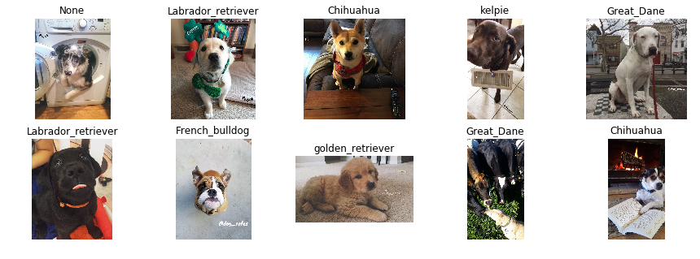

```python
from PIL import Image
from io import BytesIO
%matplotlib inline

charlies = list(twitter_archive_master.jpg_url[twitter_archive_master.name == "Charlie"])
breed = list(twitter_archive_master.p1[twitter_archive_master.name == "Charlie"])

fig, ax = plt.subplots(nrows=2, ncols=5, figsize=(15,5))

for row in ax:
    for col in row:
        response = requests.get(charlies.pop())
        img = Image.open(BytesIO(response.content))
        col.set_axis_off()
        col.set_title(breed.pop())
        col.imshow(np.asarray(img))

plt.show()
```

### Insight 3:

Let's get more technical. How about the histograms of prediction confidences of breeds.

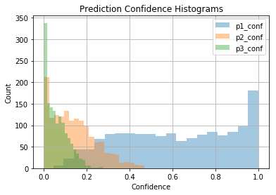

```python
plt.title("Prediction Confidence Histograms")

twitter_archive_master.p1_conf.hist(bins=20, alpha = 0.4, label="p1_conf")
twitter_archive_master.p2_conf.hist(bins=20, alpha = 0.4, label="p2_conf")
twitter_archive_master.p3_conf.hist(bins=20, alpha = 0.4, label="p3_conf")

plt.xlabel("Confidence")
plt.ylabel("Count")

plt.legend()
```

It is interesting to see that p2_conf and p3_conf have right skewed distribution, while p1_conf is roughly uniform between 1-0.3

```python
from subprocess import call
call(['python', '-m', 'nbconvert', 'wrangle_act.ipynb'])
```

```
0
```

```python
!tar cvfz wrangle.tar.gz *
```

```
act_report.html
image1.jpg
image2.jpg
image_predictions.tsv
tweet_json.txt
twitter-archive-enhanced.csv
twitter_archive_master.csv
wrangle.tar.gz
tar: wrangle.tar.gz: file changed as we read it
wrangle_act.html
wrangle_act.ipynb
wrangle_report.html
wrangle_report.ipynb
```

### Phew!.. Done

[figure not shown]